# Estimating spliced and unspliced abundances for RNA velocity with alevin

Charlotte Soneson

2020-03-22

RNA velocity ([La Manno et al., 2018](https://www.nature.com/articles/s41586-018-0414-6)) allows investigation of the dynamic patterns in single-cell RNA-seq data sets, via estimation of the abundance of intronic (“unprocessed”) and exonic (“processed”) RNA in each cell, and modelling of these via a system of ordinary differential equations. From a quantification point of view, RNA velocity analysis requires the generation of two count matrices, representing the processed and unprocessed RNA. In this tutorial, we show how these matrices can be generated using *alevin* and [*tximeta*](https://bioconductor.org/packages/tximeta/) ([Love et al., 2020](https://journals.plos.org/ploscompbiol/article?id=10.1371/journal.pcbi.1007664)). For a more detailed study of the impact of quantification on RNA velocity estimates and interpretation, see [Soneson et al., 2020](https://www.biorxiv.org/content/10.1101/2020.03.13.990069v1).

The sections below contain code chunks executed in different languages, indicated with different background colors. R code is represented by grey boxes, shell commands by blue boxes, and python code by yellow boxes. We start by loading the required R packages.

```r
suppressPackageStartupMessages({
    library(Biostrings)
    library(BSgenome)
    library(eisaR)
    library(GenomicFeatures)
    library(SummarizedExperiment)
    library(tximeta)
    library(rjson)
    library(reticulate)
    library(SingleCellExperiment)
    library(scater)
})
```

## Step 1. Generate reference fasta files

In order to quantify both exonic and intronic abundances with *alevin*, we need to provide a reference fasta file with both types of sequences. Several tools implement the extraction of transcript and intron sequences from the genome sequence. Here, we will use the [*eisaR*](https://bioconductor.org/packages/eisaR/) package, but equivalent functionality is available in the [*BUSpaRse*](https://bioconductor.org/packages/BUSpaRse/) package, and can be replicated e.g. using basic functions from the [*GenomicFeatures*](https://bioconductor.org/packages/GenomicFeatures/) and [*BSgenome*](https://bioconductor.org/packages/BSgenome/) packages.

We start by downloading the reference genome and the corresponding gtf file from the Gencode website.

```bash
wget ftp://ftp.ebi.ac.uk/pub/databases/gencode/Gencode_mouse/release_M24/gencode.vM24.annotation.gtf.gz
wget ftp://ftp.ebi.ac.uk/pub/databases/gencode/Gencode_mouse/release_M24/GRCm38.primary_assembly.genome.fa.gz
gunzip GRCm38.primary_assembly.genome.fa.gz
```

Next, we load the *eisaR* package and extract a GRanges object containing the genomic coordinates of each annotated transcript and intron. In this example, we use the ‘separate’ approach to define introns separately for each transcript, and add a flank length of 90nt to each intron. We note that the length of the flanking sequence should be chosen depending on the RNA read length and the desired amount of overlap with an intron that is required to consider a read potentially intronic. For more details on the different options, we refer to the help of the `getFeatureRanges()` function.

```r
gtf <- "gencode.vM24.annotation.gtf.gz"
grl <- eisaR::getFeatureRanges(
  gtf = gtf,
  featureType = c("spliced", "intron"),
  intronType = "separate",
  flankLength = 90L,
  joinOverlappingIntrons = FALSE,
  verbose = TRUE
)
```

```r
grl[4:6]
```

```
## GRangesList object of length 3:
## $ENSMUST00000161581.1
## GRanges object with 2 ranges and 5 metadata columns:
##       seqnames          ranges strand |              exon_id
##          <Rle>       <IRanges>  <Rle> |          <character>
##   [1]     chr1 3466587-3466687      + | ENSMUSE00000869502.1
##   [2]     chr1 3513405-3513553      + | ENSMUSE00000864479.1
##       exon_rank        transcript_id              gene_id        type
##       <integer>          <character>          <character> <character>
##   [1]         1 ENSMUST00000161581.1 ENSMUSG00000089699.1        exon
##   [2]         2 ENSMUST00000161581.1 ENSMUSG00000089699.1        exon
##   -------
##   seqinfo: 22 sequences (1 circular) from an unspecified genome; no seqlengths
##
## $ENSMUST00000192183.1
## GRanges object with 1 range and 5 metadata columns:
##       seqnames          ranges strand |              exon_id
##          <Rle>       <IRanges>  <Rle> |          <character>
##   [1]     chr1 3531795-3532720      + | ENSMUSE00001343235.1
##       exon_rank        transcript_id              gene_id        type
##       <integer>          <character>          <character> <character>
##   [1]         1 ENSMUST00000192183.1 ENSMUSG00000103147.1        exon
##   -------
##   seqinfo: 22 sequences (1 circular) from an unspecified genome; no seqlengths
##
## $ENSMUST00000193244.1
## GRanges object with 1 range and 5 metadata columns:
##       seqnames          ranges strand |              exon_id
##          <Rle>       <IRanges>  <Rle> |          <character>
##   [1]     chr1 3680155-3681788      + | ENSMUSE00001341983.1
##       exon_rank        transcript_id              gene_id        type
##       <integer>          <character>          <character> <character>
##   [1]         1 ENSMUST00000193244.1 ENSMUSG00000102348.1        exon
##   -------
##   seqinfo: 22 sequences (1 circular) from an unspecified genome; no seqlengths
```

After defining the genomic positions of all features of interest, we can extract the sequences of these, and write to a fasta file for later indexing with *Salmon*.

```r
genome <- Biostrings::readDNAStringSet(
    "GRCm38.primary_assembly.genome.fa"
)
names(genome) <- sapply(strsplit(names(genome), " "), .subset, 1)
seqs <- GenomicFeatures::extractTranscriptSeqs(
  x = genome,
  transcripts = grl
)
Biostrings::writeXStringSet(
    seqs, filepath = "gencode.vM24.annotation.expanded.fa"
)
```

To enable reading the estimated abundances with *tximeta*, automatically recognizing the underlying transcriptome, we write the expanded annotation to a GTF file. This will later be used to create a linked transcriptome for *tximeta*.

```r
eisaR::exportToGtf(
  grl,
  filepath = "gencode.vM24.annotation.expanded.gtf"
)
```

Since *alevin* quantifies spliced and unspliced features jointly, we will also need to split the imported abundances by feature type. The splitting needs to be done in such a way that we can still match up a spliced feature with the corresponding unspliced feature. To help with this, the metadata of the GRanges object contains a data frame with corresponding spliced and unspliced gene IDs.

```r
head(metadata(grl)$corrgene)
```

```
##                spliced                 intron
## 1 ENSMUSG00000102693.1 ENSMUSG00000102693.1-I
## 2 ENSMUSG00000064842.1 ENSMUSG00000064842.1-I
## 3 ENSMUSG00000102851.1 ENSMUSG00000102851.1-I
## 4 ENSMUSG00000089699.1 ENSMUSG00000089699.1-I
## 5 ENSMUSG00000103147.1 ENSMUSG00000103147.1-I
## 6 ENSMUSG00000102348.1 ENSMUSG00000102348.1-I
```

```r
write.table(
    metadata(grl)$corrgene,
    file = "gencode.vM24.annotation.expanded.features.tsv",
    row.names = FALSE, col.names = TRUE, quote = FALSE, sep = "\t"
)
```

Finally, we create a text file mapping transcript and intron identifiers to the corresponding gene identifiers.

```r
df <- eisaR::getTx2Gene(
    grl, filepath = "gencode.vM24.annotation.expanded.tx2gene.tsv"
)
```

## Step 2. Index the reference features

After creating the fasta file with transcript and intron sequences as above, we can index it using *Salmon*. Here, we add the full genome sequence as decoy sequences (see [Srivastava et al., 2019](https://www.biorxiv.org/content/10.1101/657874v2) for more details). This is recommended in order to avoid reads truly originating from intergenic regions being assigned to a suboptimal transcriptome location. However, the effect of including decoys is typically smaller when both transcripts and introns are being quantified than for ‘regular’ gene expression quantification, since in the former case a larger fraction of the genome is already covered by the features of interest.

```bash
grep ">" GRCm38.primary_assembly.genome.fa | cut -d ">" -f 2 | cut -d " " -f 1 > GRCm38.primary_assembly.genome.chrnames.txt

salmon index \
-t <(cat gencode.vM24.annotation.expanded.fa GRCm38.primary_assembly.genome.fa) \
-i gencode.vM24.annotation.expanded.sidx --gencode -p 32 \
-d GRCm38.primary_assembly.genome.chrnames.txt
```

As mentioned in the previous section, we also create a *linked transcriptome* with *tximeta*. This allows *tximeta* to recognize the reference annotation when reading the *alevin* quantification, and automatically annotate the resulting SummarizedExperiment object.

```r
tximeta::makeLinkedTxome(
  indexDir = "gencode.vM24.annotation.expanded.sidx",
  source = "GENCODE", genome = "GRCm38",
  organism = "Mus musculus", release = "M24",
  fasta = "gencode.vM24.annotation.expanded.fa",
  gtf = "gencode.vM24.annotation.expanded.gtf",
  write = TRUE, jsonFile = "gencode.vM24.annotation.expanded.json"
)
```

```r
rjson::fromJSON(file = "gencode.vM24.annotation.expanded.json")
```

```
## [[1]]
## [[1]]$index
## [1] "gencode.vM24.annotation.expanded.sidx"
##
## [[1]]$source
## [1] "GENCODE"
##
## [[1]]$organism
## [1] "Mus musculus"
##
## [[1]]$release
## [1] "M24"
##
## [[1]]$genome
## [1] "GRCm38"
##
## [[1]]$fasta
## [1] "gencode.vM24.annotation.expanded.fa"
##
## [[1]]$gtf
## [1] "gencode.vM24.annotation.expanded.gtf"
##
## [[1]]$sha256
## [1] "d99e4f1eb30d801f6bb787feeb0349e8e27b8913fa9c17f369895584475d69e8"
```

## Step 3. Quantify with alevin

After generating the index, we quantify exonic and intronic abundances with *alevin*. We use an example data set from [Hermann et al., 2018](https://www.sciencedirect.com/science/article/pii/S2211124718316024?via%3Dihub). The following code downloads the bam file from SRA and uses the bamtofastq utility to convert it into a set of FASTQ files (note that this can take a long time to execute):

```bash
wget https://sra-pub-src-1.s3.amazonaws.com/SRR6459157/AdultMouse_Rep3_possorted_genome_bam.bam.1
mv AdultMouse_Rep3_possorted_genome_bam.bam.1 AdultMouse_Rep3_possorted_genome_bam.bam
bamtofastq --reads-per-fastq=500000000 AdultMouse_Rep3_possorted_genome_bam.bam FASTQtmp
mv FASTQtmp/Ad-Ms-Total-Sorted_20k_count_MissingLibrary_1_HK2GNBBXX/bamtofastq_S1_L006_I1_001.fastq.gz AdultMouseRep3_S1_L001_I1_001.fastq.gz
mv FASTQtmp/Ad-Ms-Total-Sorted_20k_count_MissingLibrary_1_HK2GNBBXX/bamtofastq_S1_L006_R1_001.fastq.gz AdultMouseRep3_S1_L001_R1_001.fastq.gz
mv FASTQtmp/Ad-Ms-Total-Sorted_20k_count_MissingLibrary_1_HK2GNBBXX/bamtofastq_S1_L006_R2_001.fastq.gz AdultMouseRep3_S1_L001_R2_001.fastq.gz
```

Next, we run *alevin* to quantify the exonic and intronic abundances based on the index generated above.

```bash
salmon alevin -l ISR -i gencode.vM24.annotation.expanded.sidx \
-1 AdultMouseRep3_S1_L001_R1_001.fastq.gz \
-2 AdultMouseRep3_S1_L001_R2_001.fastq.gz \
-o alevin_out -p 36 --tgMap gencode.vM24.annotation.expanded.tx2gene.tsv \
--chromium --dumpFeatures --expectCells 1850
```

## Step 4. Import abundances into R with *tximeta*

The *tximeta* package can be used to import the *alevin* quantifications into R, and generate a SummarizedExperiment object. We first load the linked transcriptome generated above, and then read the *alevin* output.

```r
tximeta::loadLinkedTxome("gencode.vM24.annotation.expanded.json")
txi <- tximeta::tximeta(coldata = data.frame(
  names = "AdultMouseRep3",
  files = "alevin_out/alevin/quants_mat.gz",
  stringsAsFactors = FALSE
), type = "alevin")
```

The `txi` object contains a single assay (‘counts’) containing both spliced and unspliced abundances. In order to calculate RNA velocities, we need to split this into two matrices, one with spliced and one with unspliced abundances, with corresponding rows. This can be done using the `splitSE()` function from *tximeta*, providing the data frame linking spliced and unspliced gene identifiers that we created above. Note that *tximeta* version 1.5.30 or later is required for this step.

```r
cg <- read.delim("gencode.vM24.annotation.expanded.features.tsv",
                 header = TRUE, as.is = TRUE)
## Rename the 'intron' column 'unspliced' to make assay names compatible with scVelo
colnames(cg)[colnames(cg) == "intron"] <- "unspliced"
txis <- tximeta::splitSE(txi, cg, assayName = "counts")
```

At this point, the `txis` object contains all the information required for RNA velocity analysis. However, in order to illustrate the direct application of *scVelo* below, we convert the `txis` object to a SingleCellExperiment object and perform basic normalization and dimension reduction.

```r
txis <- as(txis, "SingleCellExperiment")
assays(txis) <- list(
    counts = assay(txis, "spliced"),
    spliced = assay(txis, "spliced"),
    unspliced = assay(txis, "unspliced")
)
txis <- scater::logNormCounts(txis)
txis <- scater::runPCA(txis)
txis <- scater::runTSNE(txis, dimred = "PCA")
```

```r
txis
```

```
## class: SingleCellExperiment
## dim: 54448 2323
## metadata(6): tximetaInfo quantInfo ... txomeInfo txdbInfo
## assays(4): counts spliced unspliced logcounts
## rownames(54448): ENSMUSG00000102693.1 ENSMUSG00000064842.1 ...
##   ENSMUSG00000064369.1 ENSMUSG00000064372.1
## rowData names(0):
## colnames(2323): ACATACGTCCTCGCAT ACACCAATCTTCGGTC ...
##   AACGTTGTCATCGATG ATTGGTGGTTACCGAT
## colData names(1): sizeFactor
## reducedDimNames(2): PCA TSNE
## altExpNames(0):
```

```r
print(sum(assay(txis, "spliced")))
```

```
## [1] 48984893
```

```r
print(sum(assay(txis, "unspliced")))
```

```
## [1] 3229763
```

## Step 5. Run scVelo

Once we have the spliced and unspliced abundance estimates, we can run, e.g., [*scVelo*](https://scvelo.readthedocs.io/) ([Bergen et al., 2019](https://www.biorxiv.org/content/10.1101/820936v1)) to estimate and visualize RNA velocities. Note that the code below represents only a simple example application to illustrate the process; please consult the *scVelo* manual for more details and updated recommendations.

First, we extract the required components of the SingleCellExperiment object in order to create an AnnData object for use in python. Note that the AnnData object is transposed compared to the SingleCellExperiment, and requires rows to represent cells and columns to represent genes.

```r
spliced <- t(assay(txis, "spliced"))
unspliced <- t(assay(txis, "unspliced"))
tsne <- reducedDim(txis, "TSNE")
pca <- reducedDim(txis, "PCA")
```

Then, we import the required python modules and initialize an AnnData object with the spliced and unspliced count matrices. For later visualization purposes, we also include the PCA and tSNE embeddings.

```python
import scanpy as sc
import sys
import numpy as np
import anndata
```

```python
adata = anndata.AnnData(X = r.spliced,
                        layers = dict(spliced = r.spliced, unspliced = r.unspliced),
                        obsm = dict(X_pca = r.pca, X_tsne = r.tsne))
```

Next, we use *scVelo* to select highly variable genes to use as the basis for the velocity calculations. We estimate the velocities using the dynamical approach, and visualize the results in the tSNE embedding calculated above.

```python
import scvelo as scv
import matplotlib
import pandas as pd

matplotlib.use('AGG')
scv.settings.set_figure_params('scvelo')
scv.utils.show_proportions(adata)
```

```
## Abundance of ['spliced', 'unspliced']: [0.94 0.06]
```

```python
scv.pp.filter_genes(adata, min_shared_counts = 30)
```

```
## Filtered out 46324 genes that are detected in less than 30 counts (shared).
```

```python
scv.pp.normalize_per_cell(adata, enforce = True)
```

```
## Normalized count data: X, spliced, unspliced.
```

```python
scv.pp.filter_genes_dispersion(adata, n_top_genes = 2000)
scv.pp.log1p(adata)

scv.pp.moments(adata, n_pcs = 30, n_neighbors = 30)
```

```
## computing neighbors
##     finished (0:00:03) --> added
##     'distances' and 'connectivities', weighted adjacency matrices (adata.obsp)
## computing moments based on connectivities
##     finished (0:00:00) --> added
##     'Ms' and 'Mu', moments of spliced/unspliced abundances (adata.layers)
```

```python
scv.tl.recover_dynamics(adata)
```

[output not shown]

[output cut: 35 more lines]

```
... 86%
... 87%
... 88%
... 89%
... 91%
... 93%
... 94%
... 95%
... 96%
... 97%
... 98%
... 98%
... 100%
    finished (0:04:36) --> added
##     'fit_pars', fitted parameters for splicing dynamics (adata.var)
```

```python
scv.tl.velocity(adata, mode = 'dynamical')
```

```
## computing velocities
##     finished (0:00:01) --> added
##     'velocity', velocity vectors for each individual cell (adata.layers)
```

```python
scv.tl.velocity_graph(adata)
```

```
## computing velocity graph
##
... 100%
    finished (0:00:01) --> added
##     'velocity_graph', sparse matrix with cosine correlations (adata.uns)
```

```python
scv.pl.velocity_embedding_stream(adata, basis='X_tsne')
```

```
## computing velocity embedding
##     finished (0:00:00) --> added
##     'velocity_tsne', embedded velocity vectors (adata.obsm)
```

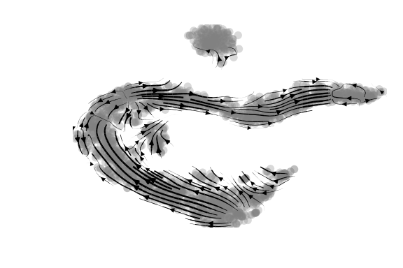

```python
scv.__version__
```

```
## '0.2.0'
```